# pbta-tumor-evolution project - PBTA Cohort - Copy data file from: ./OpenPedCan-analysis/data/v12/histologies.tsv May 1st, 2023

User ID: chronia

2023-05-05

# aim

This is an exploratory analysis of longitudinal data in the PBTA cohort. We are investigating the number of histologies (cancer_type column): (1) per assay (experimental_strategy) and (2) pairs of genomic and transcriptomic assays. We are also looking at the number of patient samples available per histology with paired genomic and transcriptomic assays for (1) each time point (disease_stage) and (2) when Diagnosis is present and paired with another point in time.

# data used

In this notebook, we are looking into the v12 histologies file (last updates on May 1st, 2023) and subset to the PBTA cohort. We use tumor_descriptor to summarize and filter disease_stages and generate “tumor_descriptor_sum”, which wa sused for downstream analysis.

# note

The colors in the plots do not match the ones of the PBTA cohort yet. —TO DO—

## Load data

```r
v12 <- readr::read_tsv(data_path)
# dim(data)
data_path_cols <- read.csv(data_path_cols, stringsAsFactor=FALSE) # Load plotting colors
merge <- merge(v12,data_path_cols,by=c('cancer_group','broad_histology'),all.x=T) #to merge tables

# to discard when add the col palette for PBTA cohort
mypalette <- brewer.pal(12,"Paired") # colorblindFriendly = TRUE
col5 <- colorRampPalette(mypalette)(5)
col8 <- colorRampPalette(mypalette)(8)
```

All tumor samples have matched normal samples. We need to filter normal samples out for further analysis. We are using “pathology_diagnosis” instead of “sample_type”. This way we discard normal samples (as shown in “sample_type”) in addition to undiagnosed tumor samples. From “composition” discard Derived Cell Line, PDX.

```r
data1 <- as.data.frame(merge)
data <- data1  %>%
   filter(cohort == "PBTA",
          !is.na(pathology_diagnosis),
          !composition %in% c("Derived Cell Line", "PDX"),
          !is.na(cancer_group)) # Discard NAs in cancer type

data %>% count(tumor_descriptor)
```

| tumor_descriptor | n |
| --- | --- |
| Deceased | 630 |
| Initial CNS Tumor | 4230 |
| Metastatic | 3 |
| Not Reported | 6 |
| Primary Tumor | 38 |
| Progressive | 676 |
| Progressive Disease Post-Mortem | 13 |
| Recurrence | 511 |
| Residual | 4 |
| Second Malignancy | 70 |

[output cut: 1 more lines]

```r
#data <- data1 %>%
#            filter(cohort == "PBTA",
#                   !is.na(pathology_diagnosis),
#                   !composition %in% c("Derived Cell Line", "PDX"),
#                   !is.na(cancer_group)) %>% # Discard NAs in cancer type
#            count(tumor_descriptor)

# Select rows with NA values in cancer_group
# df <- data[is.na(data$cancer_group), ]
# df %>% count(cancer_group)
# df %>% count(tumor_descriptor)

# Save data after filter
write.csv(data, paste0(out_path_results, "data_by_cohort_", "PBTA", "_filter.csv"))

# Replicate tumor_descriptor column and rename to tumor_descriptor_sum. This will summarize some longitudinal info.
# data %>% count(tumor_descriptor)

data$tumor_descriptor_sum <- data$tumor_descriptor
data$tumor_descriptor_sum <- ifelse(data$tumor_descriptor_sum=="Progressive Disease Post-Mortem", "Deceased",
                                 ifelse(data$tumor_descriptor_sum=="Initial CNS Tumor", "Diagnosis",
                                 ifelse(data$tumor_descriptor_sum=="Primary Tumor", "Diagnosis", data$tumor_descriptor_sum)))
data <- data %>% filter(tumor_descriptor_sum %in% c("Diagnosis", "Progressive", "Recurrence", "Deceased"))

data %>% count(tumor_descriptor_sum)
```

| tumor_descriptor_sum | n |
| --- | --- |
| Deceased | 643 |
| Diagnosis | 4268 |
| Progressive | 676 |
| Recurrence | 511 |

```r
# Save data after filter
write.csv(data, paste0(out_path_results, "data_by_cohort_", "PBTA", "_filter_logitudinal.csv"))

data %>% count(cancer_group)
```

| cancer_group | n |
| --- | --- |
| Adamantinomatous Craniopharyngioma | 207 |
| Astroblastoma | 2 |
| Astrocytoma | 1 |
| Atypical Teratoid Rhabdoid Tumor | 217 |
| Atypical choroid plexus papilloma | 10 |
| CNS Burkitt's lymphoma | 3 |
| CNS Embryonal tumor | 61 |
| CNS neuroblastoma | 10 |
| Cavernoma | 9 |
| Central neurocytoma | 9 |

[output cut: 54 more lines]

```r
data %>% count(tumor_descriptor)
```

| tumor_descriptor | n |
| --- | --- |
| Deceased | 630 |
| Initial CNS Tumor | 4230 |
| Primary Tumor | 38 |
| Progressive | 676 |
| Progressive Disease Post-Mortem | 13 |
| Recurrence | 511 |

```r
data %>% count(tumor_descriptor_sum)
```

| tumor_descriptor_sum | n |
| --- | --- |
| Deceased | 643 |
| Diagnosis | 4268 |
| Progressive | 676 |
| Recurrence | 511 |

```r
data %>% count(composition)
```

| composition | n |
| --- | --- |
| Solid Tissue | 6098 |

```r
data %>% count(pathology_diagnosis)
```

| pathology_diagnosis | n |
| --- | --- |
| Astrocytoma | 1 |
| Atypical Teratoid Rhabdoid Tumor (ATRT) | 217 |
| Brainstem glioma- Diffuse intrinsic pontine glioma | 378 |
| Cavernoma | 9 |
| Chordoma | 38 |
| Choroid plexus carcinoma | 45 |
| Choroid plexus papilloma | 93 |
| Craniopharyngioma | 262 |
| Dysembryoplastic neuroepithelial tumor (DNET) | 135 |
| Dysplasia/Gliosis;Ganglioglioma | 3 |

[output cut: 35 more lines]

```r
count1 <- data %>%
          group_by(sample_id, cohort_participant_id, Kids_First_Participant_ID,
                 experimental_strategy, sample_type, tumor_descriptor, tumor_descriptor_sum, primary_site,
                 age_at_diagnosis_days, age_last_update_days, age_at_chemo_start, age_at_radiation_start,
                 pathology_diagnosis, cancer_group, broad_histology) %>%
          dplyr::count(cancer_group)

write.csv(count1, paste0(out_path_results, "data_by_cohort_", "PBTA", "_filter_logitudinal_count.csv"))
```

## All assays

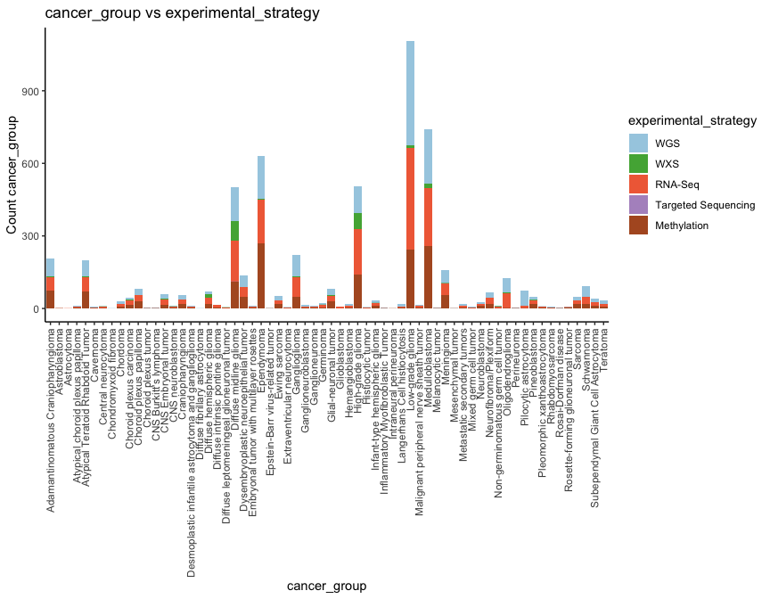

```r
count1$experimental_strategy <- factor(x = count1$experimental_strategy, levels = c("WGS", "WXS", "RNA-Seq", "Targeted Sequencing", "Methylation"))

p <- ggplot(count1, aes(x=cancer_group, fill=experimental_strategy))+
        geom_bar()+
        scale_fill_manual(values=col5) +
        theme_classic()+
        ylab("Count cancer_group") +
        ggtitle("cancer_group vs experimental_strategy") +
        guides(color=guide_legend(override.aes=list(size=3))) +
        theme(axis.text.x = element_text(angle = 90, vjust = 0.5, hjust = 1))
        print(p)
```

```r
ggsave(paste0("Barplot_cancer_group_experimental_strategy_", "PBTA", ".pdf"), plot=p, path=out_path_plots, device="pdf", height=7, width=10)
```

## Paired genomic, transcriptomic assays

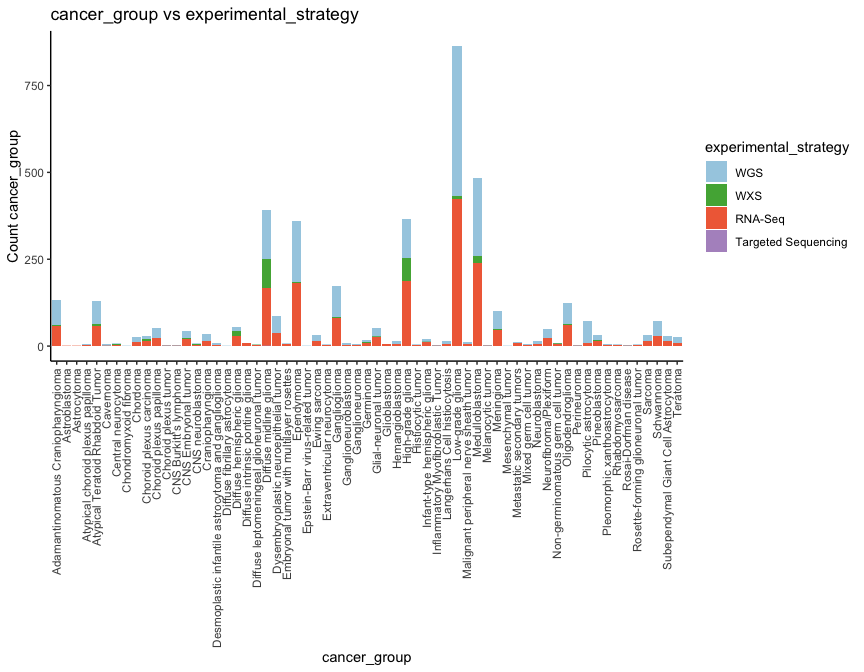

```r
count <- count1 %>% filter(experimental_strategy %in% c("WGS", "WXS", "RNA-Seq", "Targeted Sequencing")) # Not included:Methylation
count$experimental_strategy <- factor(x = count$experimental_strategy, levels = c("WGS", "WXS", "RNA-Seq", "Targeted Sequencing"))

p <- ggplot(count, aes(x=cancer_group, fill=experimental_strategy))+
        geom_bar()+
        scale_fill_manual(values=col5) + #scale_fill_manual(values=c(data$plot_group_hex))
        theme_classic()+
        ylab("Count cancer_group") +
        ggtitle("cancer_group vs experimental_strategy") +
        guides(color=guide_legend(override.aes=list(size=3))) +
        theme(axis.text.x = element_text(angle = 90, vjust = 0.5, hjust = 1))
        print(p)
```

```r
ggsave(paste0("Barplot_cancer_group_experimental_strategy_matched_DNA-RNA_", "PBTA", ".pdf"), plot=p, path=out_path_plots, device="pdf", height=7, width=10)
```

## By cancer_group - all disease stages

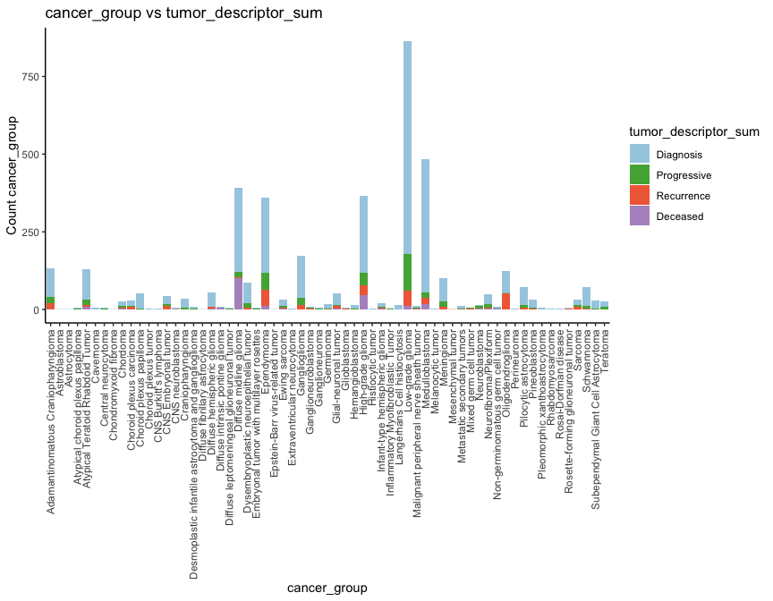

```r
count$tumor_descriptor_sum <- factor(x = count$tumor_descriptor_sum, levels = c("Diagnosis", "Progressive", "Recurrence", "Deceased"))

p <- ggplot(count, aes(x=cancer_group, fill=tumor_descriptor_sum))+
        geom_bar()+
        scale_fill_manual(values=col5) +
        theme_classic()+
        ylab("Count cancer_group") +
        ggtitle("cancer_group vs tumor_descriptor_sum") +
        guides(color=guide_legend(override.aes=list(size=3))) +
        theme(axis.text.x = element_text(angle = 90, vjust = 0.5, hjust = 1))
        print(p)
```

```r
ggsave(paste0("Barplot_cancer_group_tumor_descriptor_sum_matched_DNA-RNA_", "PBTA", ".pdf"), plot=p, path=out_path_plots, device="pdf", height=7, width=10)
```

In the following section, we will provide summary table across different disease stages, histologies, and patients samples.

### Number of tumor samples per each assay

First, we’ll examine how many of each type of assay we have (tumors only). This information is stored in the experimental_strategy column.

```r
count1 %>%
  group_by(experimental_strategy) %>%
  tally() %>%
  arrange(desc(n)) %>%
  regulartable() %>%
  fontsize(size = 12, part = "all")
```

| experimental_strategy | n |
| --- | --- |
| RNA-Seq | 1,943 |
| WGS | 1,920 |
| Methylation | 1,657 |
| WXS | 224 |
| Targeted Sequencing | 1 |

### Paired genomic, transcriptomic assays

## Multiple time points: Diagnosis, Progressive, Recurrence, Deceased

We’re going to use the `tumor_descriptor_sum` column here with matched genomic and transcriptomic assays from before.

# Disease stage - descriptors pairs

```r
disease_stage_cancer_group <- count %>%
  group_by(Kids_First_Participant_ID) %>%
  summarize(disease_stage = paste(sort(unique(tumor_descriptor_sum)),
                                  collapse = ", "),
            cancer_group = paste(sort(unique(cancer_group)),
                                collapse = ", ")) %>%
  group_by(disease_stage, cancer_group) %>%
  tally() %>%
  arrange(desc(n))

disease_stage_cancer_group %>%
  regulartable() %>%
  fontsize(size = 12, part = "all")
```

| disease_stage | cancer_group | n |
| --- | --- | --- |
| Diagnosis | Low-grade glioma | 335 |
| Diagnosis | Medulloblastoma | 231 |
| Diagnosis | High-grade glioma | 122 |
| Diagnosis | Diffuse midline glioma | 117 |
| Diagnosis | Ependymoma | 115 |
| Diagnosis | Ganglioglioma | 71 |
| Diagnosis | Pilocytic astrocytoma | 56 |
| Diagnosis | Adamantinomatous Craniopharyngioma | 49 |
| Progressive | Low-grade glioma | 48 |
| Deceased | Diffuse midline glioma | 45 |
| Diagnosis | Atypical Teratoid Rhabdoid Tumor | 43 |
| Diagnosis | Meningioma | 40 |
| Diagnosis | Dysembryoplastic neuroepithelial tumor | 38 |
| Diagnosis | Oligodendroglioma | 36 |
| Diagnosis | Schwannoma | 33 |
| Diagnosis | Choroid plexus papilloma | 31 |
| Recurrence | Oligodendroglioma | 27 |
| Diagnosis | Diffuse hemispheric glioma | 22 |
| Diagnosis | Glial-neuronal tumor | 22 |
| Deceased | High-grade glioma | 20 |
| Progressive | High-grade glioma | 17 |
| Diagnosis | Neurofibroma/Plexiform | 16 |
| Diagnosis | Pineoblastoma | 16 |
| Recurrence | Low-grade glioma | 16 |
| Diagnosis | CNS Embryonal tumor | 15 |
| Diagnosis | Craniopharyngioma | 15 |
| Diagnosis | Subependymal Giant Cell Astrocytoma | 13 |
| Diagnosis | Ewing sarcoma | 12 |
| Progressive | Ependymoma | 12 |
| Recurrence | Ependymoma | 12 |

[output cut: 190 more lines]

What about when Diagnosis is present and paired with another point in time?

```r
Diagnosis_paired <- disease_stage_cancer_group  %>%
  filter(disease_stage != "Diagnosis")  %>%
  filter(grepl("Diagnosis", disease_stage)) %>%
  regulartable() %>%
  fontsize(size = 12, part = "all")
Diagnosis_paired
```

| disease_stage | cancer_group | n |
| --- | --- | --- |
| Diagnosis, Deceased | Diffuse midline glioma | 11 |
| Diagnosis, Progressive | Ependymoma | 8 |
| Diagnosis, Progressive | Low-grade glioma | 8 |
| Diagnosis, Progressive | Medulloblastoma | 8 |
| Diagnosis, Recurrence | Low-grade glioma | 8 |
| Diagnosis, Recurrence | Ependymoma | 7 |
| Diagnosis, Deceased | High-grade glioma | 6 |
| Diagnosis, Progressive | Atypical Teratoid Rhabdoid Tumor | 5 |
| Diagnosis, Progressive | Low-grade glioma, Pilocytic astrocytoma | 5 |
| Diagnosis, Deceased | Medulloblastoma | 4 |
| Diagnosis, Progressive | Diffuse midline glioma | 4 |
| Diagnosis, Progressive, Recurrence | Ependymoma | 4 |
| Diagnosis, Deceased | Atypical Teratoid Rhabdoid Tumor | 3 |
| Diagnosis, Progressive | Meningioma | 3 |
| Diagnosis, Recurrence | Adamantinomatous Craniopharyngioma | 3 |
| Diagnosis, Progressive | Ganglioglioma | 2 |
| Diagnosis, Progressive, Recurrence | Low-grade glioma | 2 |
| Diagnosis, Recurrence | Atypical Teratoid Rhabdoid Tumor | 2 |
| Diagnosis, Recurrence | Ganglioglioma | 2 |
| Diagnosis, Recurrence | High-grade glioma | 2 |
| Diagnosis, Recurrence | Medulloblastoma | 2 |
| Diagnosis, Recurrence | Meningioma | 2 |
| Diagnosis, Deceased | Chordoma | 1 |
| Diagnosis, Deceased | Diffuse hemispheric glioma | 1 |
| Diagnosis, Deceased | Diffuse intrinsic pontine glioma, Diffuse midline glioma | 1 |
| Diagnosis, Deceased | Diffuse midline glioma, High-grade glioma | 1 |
| Diagnosis, Deceased | Ependymoma | 1 |
| Diagnosis, Deceased | Malignant peripheral nerve sheath tumor | 1 |
| Diagnosis, Progressive | Adamantinomatous Craniopharyngioma, Craniopharyngioma | 1 |
| Diagnosis, Progressive | CNS Embryonal tumor | 1 |
| Diagnosis, Progressive | Choroid plexus carcinoma | 1 |
| Diagnosis, Progressive | Diffuse leptomeningeal glioneuronal tumor, Low-grade glioma | 1 |
| Diagnosis, Progressive | Dysembryoplastic neuroepithelial tumor | 1 |
| Diagnosis, Progressive | Ganglioneuroblastoma, Neuroblastoma | 1 |
| Diagnosis, Progressive | Glial-neuronal tumor, Low-grade glioma | 1 |
| Diagnosis, Progressive | Hemangioblastoma | 1 |
| Diagnosis, Progressive | Low-grade glioma, Neurofibroma/Plexiform, Schwannoma | 1 |
| Diagnosis, Progressive | Metastatic secondary tumors | 1 |
| Diagnosis, Progressive | Neurofibroma/Plexiform | 1 |
| Diagnosis, Progressive | Schwannoma | 1 |
| Diagnosis, Progressive, Deceased | Diffuse midline glioma | 1 |
| Diagnosis, Progressive, Recurrence, Deceased | Atypical Teratoid Rhabdoid Tumor | 1 |
| Diagnosis, Recurrence | CNS Embryonal tumor | 1 |
| Diagnosis, Recurrence | CNS Embryonal tumor, Embryonal tumor with multilayer rosettes | 1 |
| Diagnosis, Recurrence | Choroid plexus carcinoma | 1 |
| Diagnosis, Recurrence | Dysembryoplastic neuroepithelial tumor, Ependymoma | 1 |
| Diagnosis, Recurrence | Ganglioglioma, Glial-neuronal tumor | 1 |
| Diagnosis, Recurrence | Glioblastoma | 1 |
| Diagnosis, Recurrence | High-grade glioma, Low-grade glioma | 1 |
| Diagnosis, Recurrence | Low-grade glioma, Pilocytic astrocytoma | 1 |
| Diagnosis, Recurrence | Medulloblastoma, Sarcoma | 1 |
| Diagnosis, Recurrence | Rosai-Dorfman disease, Sarcoma | 1 |
| Diagnosis, Recurrence | Sarcoma | 1 |
| Diagnosis, Recurrence | Schwannoma | 1 |
| Diagnosis, Recurrence, Deceased | Ependymoma | 1 |
| Diagnosis, Recurrence, Deceased | Ewing sarcoma | 1 |
| Diagnosis, Recurrence, Deceased | High-grade glioma | 1 |

## By Kids_First_Participant_ID

### Disease stage - descriptors pairs

```r
disease_stage <- count %>%
  group_by(Kids_First_Participant_ID) %>%
  summarize(disease_stage = paste(sort(unique(tumor_descriptor_sum)),
                                  collapse = ", "),
                                collapse = ", ") %>%
  group_by(disease_stage) %>%
  tally() %>%
  arrange(desc(n))

disease_stage  %>%
  regulartable() %>%
  fontsize(size = 12, part = "all")
```

| disease_stage | n |
| --- | --- |
| Diagnosis | 1,576 |
| Progressive | 170 |
| Recurrence | 139 |
| Deceased | 99 |
| Diagnosis, Progressive | 55 |
| Diagnosis, Recurrence | 40 |
| Diagnosis, Deceased | 30 |
| Progressive, Recurrence | 7 |
| Diagnosis, Progressive, Recurrence | 6 |
| Progressive, Deceased | 4 |
| Diagnosis, Recurrence, Deceased | 3 |
| Progressive, Recurrence, Deceased | 3 |
| Recurrence, Deceased | 3 |
| Diagnosis, Progressive, Deceased | 1 |
| Diagnosis, Progressive, Recurrence, Deceased | 1 |

What about when Diagnosis is present and paired with another point in time?

```r
Diagnosis_paired <- disease_stage  %>%
  filter(disease_stage != "Diagnosis")  %>%
  filter(grepl("Diagnosis", disease_stage)) %>%
  regulartable() %>%
  fontsize(size = 12, part = "all")
Diagnosis_paired
```

| disease_stage | n |
| --- | --- |
| Diagnosis, Progressive | 55 |
| Diagnosis, Recurrence | 40 |
| Diagnosis, Deceased | 30 |
| Diagnosis, Progressive, Recurrence | 6 |
| Diagnosis, Recurrence, Deceased | 3 |
| Diagnosis, Progressive, Deceased | 1 |
| Diagnosis, Progressive, Recurrence, Deceased | 1 |